# Vehicular Messaging Simulation

Clustered Epidemiological Differential Equations

Jungyeol Kim

Contents

- Introduction
  - Recommended citation
  - Setting
    - File 1: `mobility-network.csv`
    - File 2: `communication-network.csv`
    - File 3: `initial-condition.csv`
- Mobility and Communicatoin Network
  - Importing edge list of mobility network
  - Importing edge list of communication network
  - Defining a neighborhood of a cluster
- Generation of Differential Equations
- Solving Differential Equations
  - Initial condition
  - Solution of differential equations
- Generating Figures
  - Fraction of overall informed vehicles over time
  - Fraction of informed and non-informed vehicles per cluster over time

## Introduction

V2V technologies bridge two infrastructures: communication and transportation. These infrastructures are interconnected and interdependent. To capture this inter-dependence, which may vary in time and space, we propose a new methodology for modeling information propagation between V2V-enabled vehicles. The model is based on a continuous-time Markov chain which is shown to converge, under appropriate conditions, to a set of clustered epidemiological differential equations. The fraction of vehicles which have received a message, as a function of space and time may be obtained as a solution of these differential equations, which can be solved efficiently, independently of the number of vehicles.

### Recommended citation

Please cite our paper below if you use this code.

*J. Kim, S. Sarkar, S. S. Venkatesh, M. S. Ryerson, and D. Starobinski, 2019. An Epidemiological Diffusion Framework for Vehicular Messaging in General Transportation Networks. (In press) Transportation Research Part B: Methodological.*

And respective BibTeX entry:

@article{KSVRS18,  
title={An Epidemiological Diffusion Framework for Vehicular Messaging in General Transportation Networks},  
author={Kim, Jungyeol and Sarkar, Saswati and Venkatesh, Santosh S and Ryerson, Megan Smirti and Starobinski, David},  
journal={(In press) Transportation Research Part B: Methodological},  
year={2019},  
publisher={Elsevier}  
}

### Setting

Objective: Our goal is to model the spread of V2V messages and obatin the fraction of vehicles which have received a message in **arbitrary transportation networks**, as a function of space and time, using a set of *clustered epidemiological differential equations*.

The following three files are required to use this software: `mobility-network.csv`, `communication-network.csv`, and `initial-condition.csv`

All the csv files should be located in your workspace.

#### File 1: `mobility-network.csv`

- This file can be configured with different values depending on vehicle movement pattern and the (arbitrary) road topology you are considering.
- The table below is an example of this csv file. The mobility rate (set in this model) from cluster $i$ to $j$ is given by
  $$\lambda^I_{ij}=\lambda^S_{ij}=p_{ij}\lambda.$$
  The mobility constatnt $\lambda$ can be determinded by the characteristic of each road segment. Speed limits are applied differently depending on the local characteristics of each city and the type of road, and as a result the average speed of the vehicles will depend on these characteristics.

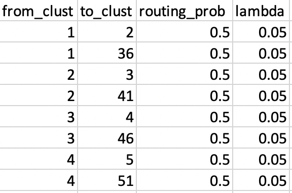

#### File 2: `communication-network.csv`

- The file contains three columns `(cluster_i, cluster_j, beta_ij)`. We will use the data set to import the given undirected communication network and communication rates between clusters. Below is a quick description of all the features in the data set.

  | Feature | Description |
  | --- | --- |
  | cluster_i | One of the endpoints of the undirected edge in the communication network |
  | cluster_j | The other endpoint of the same undirected edge in the communication network |
  | beta_ij | Parameter for communications between cluster $i$ and $j$; $\beta_{ij}$ |

- The table below is an example of this csv file. The communication parameter `beta_ij` is same as $\beta_{ij}$ in the differential equations.

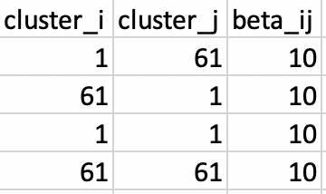

#### File 3: `initial-condition.csv`

- The file contains three columns `(cluster, I_ini, S_ini)`. We will use the data set to import the given initial condition. Below is a quick description of all the features in the data set.

  | Feature | Description |
  | --- | --- |
  | cluster | Cluster number |
  | I_ini | Fraction of informed vehicles in each cluster at initial time; the number of informed vehicle per cluster divided by the total number of vehicles |
  | S_ini | Fraction of non-informed vehicles in each cluster at initial time; the number of non-informed vehicle per cluster divided by the total number of vehicles |

- Constraints: I_{ini}$\geq 0$, S_{ini}$\geq 0$, and $\sum_{i=1}^{J} ($I_{ini}+S_{ini}$)=1$.
- The table below is an example of this csv file.

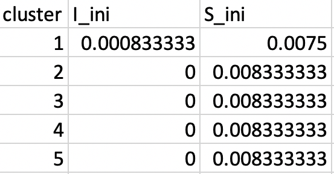

### Case study: Grid road topology

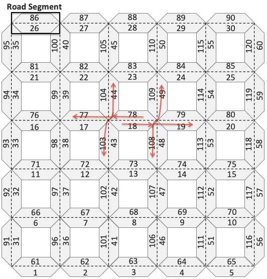

As an example, we consider the grid road topology with six avenues and streets. In this network, we assume that all roads are two-way and allow vehicles to move in both directions, and a road segment consists of two clusters corresponding to the opposite directional roads. Since two clusters on the same road segment are sufficiently close to each other, we also assume that the vehicles located in these can communicate; there is an undirected edge between the two clusters on the same road segment.

Under these settings, we can create three files that are essential for the vehicular messaging simulation using clustered epidemiological differential equations. The files I have already created under these assumptions can be downloaded from the following GitHub repository: https://github.com/jungyeol-kim/V2X-simulations.

## Mobility and Communication Network

### Importing edge list of mobility network

We import pre-defined edge list of directed mobility network and corresponding mobility parameter $\lambda_{ij}$

```r
setwd("/Users/jy/Dropbox/1. PENN - Doctorate/Research/Epidemics on Vehicular Networks/Updates/Transportation Research Part B/4th Round (final)/Final (Nov 14)/V2X-simulations")
mobility_network<-read.csv("mobility-network.csv", header=T, as.is=T)
mobility_network$lambda_from_to<-mobility_network$routing_prob*mobility_network$lambda
```

```r
head(mobility_network) #View(mobility_network)
```

```
##   from_clust to_clust routing_prob lambda lambda_from_to
## 1          1        2          0.5   0.05          0.025
## 2          1       36          0.5   0.05          0.025
## 3          2        3          0.5   0.05          0.025
## 4          2       41          0.5   0.05          0.025
## 5          3        4          0.5   0.05          0.025
## 6          3       46          0.5   0.05          0.025
```

### Importing edge list of communication network

We import pre-defined edge list of undirected communication network and corresponding communication parameter $\beta_{ij}$

```r
communication_network<-read.csv("communication-network.csv", header=T, as.is=T)
communication_network<-communication_network[order(communication_network$cluster_i,communication_network$cluster_j),]
rownames(communication_network) <- NULL # reset row names
```

```r
head(communication_network) #View(communication_network)
```

```
##   cluster_i cluster_j beta_ij
## 1         1         1      10
## 2         1        61      10
## 3         2         2      10
## 4         2        62      10
## 5         3         3      10
## 6         3        63      10
```

### Defining a neighborhood of a cluster

We define a neighborhood of each cluster for both directed mobility network and undirected communication network.

```r
total.clusters<-120
mob.edge.out<-vector(mode='list',length=total.clusters)
# outgoing edges from node i in the mobility network
mob.edge.out.rate<-vector(mode='list',length=total.clusters)
# mobility parameter of outgoing edges from node i in the mobility network
mob.edge.in<-vector(mode='list',length=total.clusters)
# incoming edges to node i in the mobility network
mob.edge.in.rate<-vector(mode='list',length=total.clusters)
# mobility parameter of incoming edges from node i in the mobility network
comm.edge<-vector(mode='list',length=total.clusters)
# undirected edges from or to node i in the communication network
comm.edge.rate<-vector(mode='list',length=total.clusters)
# communication parameter of undirected edges from or to node i in the communication network
for (i in 1:total.clusters) {
  temp1<-mobility_network[mobility_network$from_clust==i,]
  temp2<-communication_network[communication_network$cluster_i==i,]
  mob.edge.out[[i]]<-temp1$to_clust
  mob.edge.out.rate[[i]]<-temp1$lambda_from_to
  comm.edge[[i]]<-temp2$cluster_j
  comm.edge.rate[[i]]<-temp2$beta_ij
  for(j in 1:length(mob.edge.out[[i]])){
    mob.edge.in[[mob.edge.out[[i]][j]]]<-c(mob.edge.in[[mob.edge.out[[i]][j]]],i)
    mob.edge.in.rate[[mob.edge.out[[i]][j]]]<-c(mob.edge.in.rate[[mob.edge.out[[i]][j]]],mob.edge.out.rate[[i]][j])
  }
}
```

**Quick exploration of the result**

```r
mob.edge.out[[1]] #View(end point of outgoing edges from a given cluster 1)
```

```
## [1]  2 36
```

```r
mob.edge.out.rate[[1]] #View(mobility rates corresponding to outgoing edges from a given cluster 1)
```

```
## [1] 0.025 0.025
```

```r
mob.edge.in[[7]] #View(mobility_network)
```

```
## [1]  6 36 97
```

```r
mob.edge.in.rate[[7]] #View(communication_network)
```

```
## [1] 0.01666667 0.01666667 0.01666667
```

```r
comm.edge[[25]] #View(mobility_network)
```

```
## [1] 25 85
```

```r
comm.edge.rate[[25]] #View(communication_network)
```

```
## [1] 10 10
```

## Generation of Differential Equations

Recall that under the conditions of our model, for a given choice of initial conditions $\bigl({\bf I}(0), {\bf S}(0)\bigr)$, the time-evolution, $\bigl({\bf I}(t), {\bf S}(t)\bigr)$, of the distribution of the asymptotic fraction of informed and non-informed vehicles across clusters is governed by the following system of ordinary differential equations:

$$\dot{I}_j(t)=-\sum_{k\neq j}^{J} \lambda^I_{jk}\left({\bf{I,S}}\right) \cdot I_j + \sum_{k=1}^{J}\beta_{kj} \cdot I_k\cdot S_j + \sum_{k\neq j}^{J} \lambda^I_{kj}\left({\bf{I,S}}\right)\cdot I_k \qquad (j=1,2,\dots,J),$$
$$\dot{S}_j(t)=-\sum_{k\neq j}^{J}\lambda^S_{jk}\left({\bf{I,S}}\right) \cdot S_j - \sum_{k=1}^{J}\beta_{kj} \cdot I_k \cdot S_j + \sum_{k\neq j}^{J}\lambda^S_{kj}\left({\bf{I,S}}\right) \cdot S_k \qquad (j=1,2,\dots,J).$$

We now create a set of *clustered epidemiological differential equations* for the given mobility and communicatoin networks. The number of variables and the total number of differential equations are $2J$ each (recall that $J$ is the total number of clusters).

**We create the first summation term on right hand side** The first summation terms on the RHS of the $j-th$ equation ($\dot{I}_j$) and the $J+j-th$ equation ($\dot{S}_j$) is related to the outgoing mobility from cluster $j$.

```r
mob.out.text<-vector(mode='character',length=total.clusters*2)
for(i in 1:total.clusters){
  mob.out.text.temp.1<-c();  mob.out.text.temp.2<-c();
  mob.out.text.temp.3<-c();  mob.out.text.temp.4<-c()
  for(j in 1:length(mob.edge.out[[i]])){
    mob.out.text.temp.1<-paste("- ",mob.edge.out.rate[[i]][j],"*y[",i,"]", sep="")
    mob.out.text.temp.2<-paste(mob.out.text.temp.2,mob.out.text.temp.1,sep=" ")
    mob.out.text.temp.3<-paste("- ",mob.edge.out.rate[[i]][j],"*y[",total.clusters+i,"]", sep="")
    mob.out.text.temp.4<-paste(mob.out.text.temp.4,mob.out.text.temp.3,sep=" ")
  }
  mob.out.text[i]<-mob.out.text.temp.2
  mob.out.text[total.clusters+i]<-mob.out.text.temp.4
}
```

```r
head(mob.out.text) #View(the first summation term on the RHS of each differential equation)
```

```
## [1] " - 0.025*y[1] - 0.025*y[1]"
## [2] " - 0.025*y[2] - 0.025*y[2]"
## [3] " - 0.025*y[3] - 0.025*y[3]"
## [4] " - 0.025*y[4] - 0.025*y[4]"
## [5] " - 0.05*y[5]"
## [6] " - 0.01666666665*y[6] - 0.01666666665*y[6] - 0.01666666665*y[6]"
```

**We create the second summation term on right hand side** The second summation terms on the RHS of the j-th equation ($\dot{I}_j$) and the (J+j)-th equation ($\dot{S}_j$) is related to the intra- and inter-communication in cluster $j$.

```r
comm.text<-vector(mode='character',length=total.clusters*2)
for(i in 1:total.clusters){
  comm.text.temp.1<-c();  comm.text.temp.2<-c();
  comm.text.temp.3<-c();  comm.text.temp.4<-c()
  for(j in 1:length(comm.edge[[i]])){
    comm.text.temp.1<-paste(comm.edge.rate[[i]][j],"*y[",comm.edge[[i]][j],"]*y[",total.clusters+i,"]", sep="")
    comm.text.temp.2<-paste(comm.text.temp.2," + ",comm.text.temp.1,sep="")
    comm.text.temp.3<-paste(comm.edge.rate[[i]][j],"*y[",comm.edge[[i]][j],"]*y[",total.clusters+i,"]", sep="")
    comm.text.temp.4<-paste(comm.text.temp.4," - ",comm.text.temp.3,sep="")
  }
  comm.text[i]<-comm.text.temp.2
  comm.text[total.clusters+i]<-comm.text.temp.4
}
```

```r
head(comm.text) #View(the second summation term on the RHS of each differential equation)
```

```
## [1] " + 10*y[1]*y[121] + 10*y[61]*y[121]"
## [2] " + 10*y[2]*y[122] + 10*y[62]*y[122]"
## [3] " + 10*y[3]*y[123] + 10*y[63]*y[123]"
## [4] " + 10*y[4]*y[124] + 10*y[64]*y[124]"
## [5] " + 10*y[5]*y[125] + 10*y[65]*y[125]"
## [6] " + 10*y[6]*y[126] + 10*y[66]*y[126]"
```

**We create the third summation term on right hand side** The third summation terms on the RHS of the j-th equation ($\dot{I}_j$) and the (J+j)-th equation ($\dot{S}_j$) is related to the incoming mobility to cluster $j$

```r
mob.in.text<-vector(mode='character',length=total.clusters*2)
for(i in 1:total.clusters){
  mob.in.text.temp.1<-c();  mob.in.text.temp.2<-c();
  mob.in.text.temp.3<-c();  mob.in.text.temp.4<-c()
  for(j in 1:length(mob.edge.in[[i]])){
    mob.in.text.temp.1<-paste(mob.edge.in.rate[[i]][j],"*y[",mob.edge.in[[i]][j],"]", sep="")
    mob.in.text.temp.2<-paste(mob.in.text.temp.2," + ",mob.in.text.temp.1,sep=" ")
    mob.in.text.temp.3<-paste(mob.edge.in.rate[[i]][j],"*y[",total.clusters+mob.edge.in[[i]][j],"]", sep="")
    mob.in.text.temp.4<-paste(mob.in.text.temp.4," + ",mob.in.text.temp.3,sep=" ")
  }
  mob.in.text[i]<-mob.in.text.temp.2
  mob.in.text[total.clusters+i]<-mob.in.text.temp.4
}
```

```r
head(mob.in.text) #View(the third summation term on the RHS of each differential equation)
```

```
## [1] "  +  0.05*y[91]"                  "  +  0.025*y[1]  +  0.025*y[96]"
## [3] "  +  0.025*y[2]  +  0.025*y[101]" "  +  0.025*y[3]  +  0.025*y[106]"
## [5] "  +  0.025*y[4]  +  0.025*y[111]" "  +  0.025*y[31]  +  0.025*y[92]"
```

**We now combine the all terms to create the complete set of differential equations**

```r
dy<-vector(mode='character',length=total.clusters*2)
for (i in 1:(total.clusters*2)) {
   dy[i]<-paste("dy",i," <- ",mob.out.text[i],mob.in.text[i],comm.text[i],sep="")
}
```

```r
head(dy) # View(complete set of differential equations)
```

```
## [1] "dy1 <-  - 0.025*y[1] - 0.025*y[1]  +  0.05*y[91] + 10*y[1]*y[121] + 10*y[61]*y[121]"
## [2] "dy2 <-  - 0.025*y[2] - 0.025*y[2]  +  0.025*y[1]  +  0.025*y[96] + 10*y[2]*y[122] + 10*y[62]*y[122]"
## [3] "dy3 <-  - 0.025*y[3] - 0.025*y[3]  +  0.025*y[2]  +  0.025*y[101] + 10*y[3]*y[123] + 10*y[63]*y[123]"
## [4] "dy4 <-  - 0.025*y[4] - 0.025*y[4]  +  0.025*y[3]  +  0.025*y[106] + 10*y[4]*y[124] + 10*y[64]*y[124]"
## [5] "dy5 <-  - 0.05*y[5]  +  0.025*y[4]  +  0.025*y[111] + 10*y[5]*y[125] + 10*y[65]*y[125]"
## [6] "dy6 <-  - 0.01666666665*y[6] - 0.01666666665*y[6] - 0.01666666665*y[6]  +  0.025*y[31]  +  0.025*y[92] + 10*y[6]*y[126] + 10*y[66]*y[126]"
```

```r
dy_name<-c()
for (i in 1:(total.clusters*2)) {
  if(i==1){dy_name<-paste(dy_name,"list(c(dy1",sep="")}
  else if(i==(total.clusters*2)){dy_name<-paste(dy_name,",dy",total.clusters*2,"))}",sep="")}
  else{dy_name<-paste(dy_name,",",paste("dy",i,sep=""),sep="")}
}
set.diff.eqn<-c("f <- function(t, y, parms) {",dy,dy_name)
write(set.diff.eqn, file = "set_diff_eqn.R")
source("set_diff_eqn.R")
```

## Solving Differential Equations

### Initial condition

We import preset initial conditions.

```r
initial_condition<-read.csv("initial-condition.csv", header=T, as.is=T) # import preset initial condition
yini<-c(initial_condition$I_ini,initial_condition$S_ini) # initial condition: 2J-dimensional vector
```

The $2J$-dimensional vector $(y_1,y_2,...,y_J; y_{J+1},y_{J+2},...,y_{2J})=(I_1,I_2,...,I_J; S_1,S_2,...,S_J)$ represent the instantaneous state of the system, semicolon and extra spacing have been added merely for visual separation of informed and non-informed vehicular counts in the various clusters.

### Solution of differential equations

We create a function to encode the set of differential equations in a form suitable for use as the `func` argument to `ode` (numerical methods provided by the `deSolve` package).

Before we run, we need to set what are the timestamps used. `times` denote time sequence for which output is wanted.

The example below shows that the result will be generated every `step.size=1` time unit, from `0` to `sim.time=100` units.

```r
sim.time<-100
step.size<-1
times <- seq(from = 0, to = sim.time, by = step.size) # output wanted at these time intervals
print(times)
```

```
##   [1]   0   1   2   3   4   5   6   7   8   9  10  11  12  13  14  15  16
##  [18]  17  18  19  20  21  22  23  24  25  26  27  28  29  30  31  32  33
##  [35]  34  35  36  37  38  39  40  41  42  43  44  45  46  47  48  49  50
##  [52]  51  52  53  54  55  56  57  58  59  60  61  62  63  64  65  66  67
##  [69]  68  69  70  71  72  73  74  75  76  77  78  79  80  81  82  83  84
##  [86]  85  86  87  88  89  90  91  92  93  94  95  96  97  98  99 100
```

We then compute the fracton of informed vehicles over space and time by applying all into the `ODE` solver:

```r
out <- ode(times = times, y=yini, func = f, parms = NULL) # numerically solve the set of differential equations
solution<-out[,-1]
rownames(solution)<-times

frac.inf.clust<-solution[,1:total.clusters] # fraction of informed vehicles per cluster
frac.non.inf.clust<-solution[,(1+total.clusters):(2*total.clusters)]; colnames(frac.non.inf.clust)<-1:total.clusters # fraction of non-informed vehicles per cluster

write.table(frac.inf.clust, file = "fraction_of_informed_vehicles_per_cluster.csv",row.names=TRUE,col.names=TRUE, sep=",") # export a matrix to a file.
write.table(frac.non.inf.clust, file = "fraction_of_non_informed_vehicles_per_cluster.csv",row.names=TRUE,col.names=TRUE, sep=",") # export a matrix to a file.
```

Row names and Column names of `frac.inf.clust` and `frac.non.inf.clust` represent time and cluster respectively. For example, `frac.inf.clust[rownames(frac.inf.clust)==10,25]` (`frac.non.inf.clust[rownames(frac.non.inf.clust)==10,25]`) gives the fraction of informed (non-informed) vehicles at $t=10$ in cluster 25. Naturally, multiplying the matrix `frac.inf.clust` (`frac.non.inf.clust`) by the total number of vehicles yields the number of informed (non-informed) vehicles in a given cluster at a given time.

```r
head(frac.inf.clust) # View(fraction of informed vehicles at a given time in each cluster)
```

```
##              1            2            3            4            5
## 0 0.0008333330 0.000000e+00 0.000000e+00 0.000000e+00 0.000000e+00
## 1 0.0008570283 2.153502e-05 2.742762e-07 3.458794e-09 4.070297e-11
## 2 0.0008866241 4.467211e-05 1.129462e-06 2.138115e-08 3.472434e-10
## 3 0.0009224916 6.983034e-05 2.639884e-06 7.020836e-08 1.509739e-09
## 4 0.0009649812 9.741283e-05 4.886947e-06 1.667595e-07 4.435826e-09
## 5 0.0010145891 1.280043e-04 8.000834e-06 3.369939e-07 1.088772e-08
##              6            7            8            9           10
## 0 0.000000e+00 0.000000e+00 0.000000e+00 0.000000e+00 0.000000e+00
## 1 3.065389e-08 1.831403e-07 3.843117e-09 5.728566e-11 3.262923e-15
## 2 1.887809e-07 7.554370e-07 2.377566e-08 4.888356e-10 5.218208e-12
## 3 6.169624e-07 1.770591e-06 7.815003e-08 2.126314e-09 3.916361e-11
## 4 1.458011e-06 3.289197e-06 1.858284e-07 6.250678e-09 1.508577e-10
## 5 2.927579e-06 5.410205e-06 3.760688e-07 1.535273e-08 4.579755e-10
##             11           12           13           14           15
```

[output cut: 153 more lines]

We export the results to csv files in the current workspace.

```r
write.table(frac.inf.clust, file = "fraction_of_informed_vehicles_per_cluster.csv",row.names=TRUE,col.names=TRUE, sep=",") # export a matrix to a file.
write.table(frac.non.inf.clust, file = "fraction_of_non_informed_vehicles_per_cluster.csv",row.names=TRUE,col.names=TRUE, sep=",") # export a matrix to a file.
```

## Generating Figures

### Fraction of overall informed vehicles over time

To study the degree of information propagation, we plot the fraction of overall vehicles that are informed at time t. A value of 1 on the y axis indicates that all vehicles in the system receive messages via V2V communication.

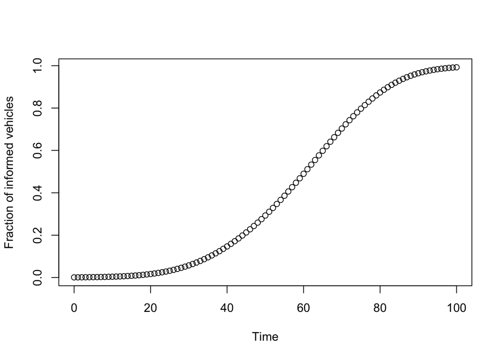

```r
frac.inf.veh<-rowSums(solution[,1:total.clusters]) #fraction of overall vehicles that are informed over time.
plot(times,frac.inf.veh, xlab="Time", ylab="Fraction of informed vehicles")
```

### Fraction of informed and non-informed vehicles over time per cluster

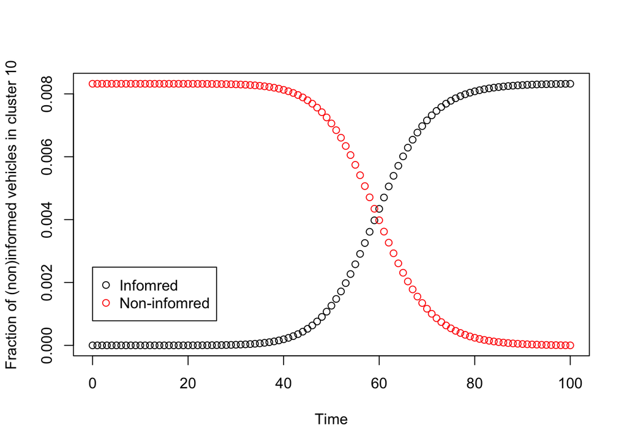

```r
cluster.specific<-10 # determine the specific cluster of interest.
frac.inf.veh.clust<-frac.inf.clust[,cluster.specific] # fraction of vehicles that are informed over time in the particular cluster.
frac.non.inf.veh.clust<-frac.non.inf.clust[,cluster.specific] # fraction of vehicles that are informed over time in the particular cluster.

plot(times, frac.inf.veh.clust, xlab="Time", col="black", ylab=paste("Fraction of (non)informed vehicles in cluster ",cluster.specific,sep = ""))
par(new=T)
plot(times, frac.non.inf.veh.clust, xlab='', ylab='', col="red", axes=F)
par(new=F)
legend(0, 0.0025, legend=c("Infomred","Non-infomred"), pch = c(1, 1), col=c("black","red"))
```